> **เปิดใน Google Colab** — คลิกป้ายด้านบน รันได้ทันทีบนคลาวด์ฟรี ไม่ต้องติดตั้งอะไรในเครื่อง (เซลล์แรกจะ `pip install` ให้เอง)

# 🗺️ แผนที่ความหมาย — จาก Dataset → Embed → Visualization

Notebook นี้คือ "บทความที่รันได้": อ่านจากบนลงล่าง กด Run ทีละเซลล์ แล้วคุณจะได้ **แผนที่ความหมายของคำ** แบบเดียวกับในหนังสือ *Second Brain ด้วย Vector Search* — ด้วยข้อมูลของคุณเอง

**สิ่งที่จะได้เรียน:**

1. สร้าง dataset คำ/ประโยค (แก้เป็นของคุณเองได้)
2. แปลงเป็นเวกเตอร์ด้วย **bge-m3** (โมเดล multilingual ที่เข้าใจไทย)
3. วัดความใกล้ด้วย **cosine similarity** (สมการเดียว)
4. ฉายลง 2 มิติด้วย **PCA** แล้ววาดแผนที่
5. อ่านผลอย่างถูกต้อง — ทำไมบางคำ "ดูใกล้" ทั้งที่ไม่เกี่ยว

> ใช้ได้ทั้ง **Google Colab** (แนะนำ — ฟรี, ไม่ต้องติดตั้งอะไรในเครื่อง) และ Jupyter ในเครื่อง

## ขั้นที่ 0 — ติดตั้ง (ครั้งเดียว ~2 นาที)

ใน Colab: กด Run เซลล์ล่างได้เลย · ในเครื่อง: ใช้ venv ก็ได้

```python
import sys, platform
IN_COLAB = 'google.colab' in sys.modules

if IN_COLAB:
    %pip -q install chromadb sentence-transformers scikit-learn matplotlib
    import subprocess, matplotlib, matplotlib.font_manager as fm
    subprocess.run(['apt-get', '-qq', 'install', '-y', 'fonts-thai-tlwg'], capture_output=True)
    for f in fm.findSystemFonts(fontpaths=['/usr/share/fonts/truetype/tlwg']):
        fm.fontManager.addfont(f)
    matplotlib.rcParams['font.family'] = 'Loma'
else:
    # เครื่องเรา: เลือก kernel "Python (vector-book)" (มี dependency ครบแล้ว)
    import matplotlib
    matplotlib.rcParams['font.family'] = 'Thonburi' if platform.system() == 'Darwin' else 'Loma'
matplotlib.rcParams['axes.unicode_minus'] = False
print('สภาพแวดล้อม:', 'Google Colab' if IN_COLAB else 'เครื่องเรา (kernel vector-book)', '· พร้อม ✓')
```

```
สภาพแวดล้อม: เครื่องเรา (kernel vector-book) · พร้อม ✓
```

## ขั้นที่ 1 — Dataset: คำของเรา

จัดคำเป็นกลุ่มไว้ **เพื่อระบายสีตอนวาดเท่านั้น** — โมเดลไม่เห็นชื่อกลุ่มเลย ถ้าแผนที่ออกมากองตรงกลุ่มสี แปลว่าโมเดลจัดกลุ่มเองได้จริง

💡 **ลองแก้เป็นคำของคุณเอง** — หัวข้องานวิจัย, ชื่อวิชา, เมนูโปรด แล้วรันใหม่ทั้งหมด

```python
WORDS = {
    'สัตว์เลี้ยง':   ['แมว', 'ลูกแมว', 'หมา', 'ลูกหมา', 'กระต่าย', 'cat', 'puppy'],
    'อาหาร':        ['ต้มยำกุ้ง', 'ผัดไทย', 'ส้มตำ', 'กาแฟลาเต้', 'ชาเขียว'],
    'การเรียนการสอน': ['ประชุมกับอาจารย์', 'นัดหมายสัมมนา', 'workshop', 'สอนนักศึกษา', 'งานวิจัย'],
    'การเงิน':       ['บิตคอยน์', 'ราคาหุ้น', 'อัตราดอกเบี้ย', 'เงินเฟ้อ'],
    'เทคโนโลยี':     ['vector search', 'embedding', 'ปัญญาประดิษฐ์', 'ฐานข้อมูล'],
}

labels = [w for ws in WORDS.values() for w in ws]
groups = [g for g, ws in WORDS.items() for _ in ws]
print(f'ทั้งหมด {len(labels)} คำ ใน {len(WORDS)} กลุ่ม')
```

```
ทั้งหมด 25 คำ ใน 5 กลุ่ม
```

## ขั้นที่ 2 — Embed: ข้อความ → เวกเตอร์ 1024 มิติ

ใช้ **BAAI/bge-m3** — โมเดล multilingual (100+ ภาษา รวมไทย) ตัวเดียวกับที่ ARRA Oracle ใช้ใน production · ครั้งแรกจะโหลดโมเดล ~2GB (Colab ฟรีรันได้)

```python
# ---- ตัว embed อัจฉริยะ: เครื่องเรา→Ollama (เร็ว+privacy) · Colab→sentence-transformers ----
import urllib.request, json
import numpy as np

def _ollama_ok():
    try:
        urllib.request.urlopen('http://localhost:11434/api/tags', timeout=2)
        return True
    except Exception:
        return False

if _ollama_ok():
    def embed_texts(texts):
        req = urllib.request.Request('http://localhost:11434/api/embed',
            data=json.dumps({'model': 'bge-m3', 'input': list(texts)}).encode(),
            headers={'Content-Type': 'application/json'})
        with urllib.request.urlopen(req, timeout=180) as r:
            V = np.array(json.load(r)['embeddings'])
        return V / np.linalg.norm(V, axis=1, keepdims=True)
    print('embed ด้วย bge-m3 ผ่าน Ollama (local, ข้อมูลไม่ออกเครื่อง) ✓')
else:
    from sentence_transformers import SentenceTransformer
    _model = SentenceTransformer('BAAI/bge-m3')
    def embed_texts(texts):
        return _model.encode(list(texts), normalize_embeddings=True)
    print('embed ด้วย bge-m3 ผ่าน sentence-transformers ✓')

import numpy as np
V = embed_texts(labels)   # normalize → cosine = dot เฉยๆ
print('รูปร่างข้อมูล:', V.shape)   # (25, 1024) — 25 คำ คำละ 1024 ตัวเลข
print('ตัวอย่าง 6 มิติแรกของ "แมว":', np.round(V[0][:6], 3))
```

```
embed ด้วย bge-m3 ผ่าน Ollama (local, ข้อมูลไม่ออกเครื่อง) ✓
```

```
รูปร่างข้อมูล: (25, 1024)
ตัวอย่าง 6 มิติแรกของ "แมว": [-0.035  0.025 -0.057  0.012 -0.002 -0.028]
```

> 🏠 **ทางเลือกสำหรับคนรันในเครื่อง + มี [Ollama](https://ollama.com):** แทนเซลล์บนด้วย

> ```
> import urllib.request, json, numpy as np
> def embed(texts):
>     req = urllib.request.Request('http://localhost:11434/api/embed',
>         data=json.dumps({'model': 'bge-m3', 'input': texts}).encode(),
>         headers={'Content-Type': 'application/json'})
>     with urllib.request.urlopen(req) as r:
>         return np.array(json.load(r)['embeddings'])
> V = embed(labels); V = V / np.linalg.norm(V, axis=1, keepdims=True)
> ```

> ได้ผลเหมือนกัน (โมเดลเดียวกัน) — และข้อมูลไม่ออกจากเครื่องเลย

## ขั้นที่ 3 — Cosine Similarity: สมการเดียวที่ต้องรู้

$$\cos(A,B) = \frac{A \cdot B}{\|A\|\,\|B\|}$$

เรา normalize เวกเตอร์ไปแล้ว (‖v‖=1) → cosine เหลือแค่ dot product → คูณ matrix ทีเดียวได้คะแนน **ทุกคู่พร้อมกัน**

```python
S = V @ V.T          # (25×25) — คะแนนความใกล้ทุกคู่

def sim(a, b):
    return S[labels.index(a), labels.index(b)]

print(f"cos(แมว, ลูกแมว)              = {sim('แมว', 'ลูกแมว'):.3f}   ← ใกล้จริง")
print(f"cos(แมว, cat)                 = {sim('แมว', 'cat'):.3f}   ← ข้ามภาษา!")
print(f"cos(ประชุมกับอาจารย์, นัดหมายสัมมนา) = {sim('ประชุมกับอาจารย์', 'นัดหมายสัมมนา'):.3f}")
print(f"cos(ปัญญาประดิษฐ์, เงินเฟ้อ)     = {sim('ปัญญาประดิษฐ์', 'เงินเฟ้อ'):.3f}   ← แทบไม่เกี่ยว")
```

```
cos(แมว, ลูกแมว)              = 0.888   ← ใกล้จริง
cos(แมว, cat)                 = 0.781   ← ข้ามภาษา!
cos(ประชุมกับอาจารย์, นัดหมายสัมมนา) = 0.757
cos(ปัญญาประดิษฐ์, เงินเฟ้อ)     = 0.543   ← แทบไม่เกี่ยว
```

### 📏 สเกลอ่านคะแนน (สำคัญมาก)

| คะแนน | ความหมาย | ตัวอย่างจากข้อมูลจริง |
| --- | --- | --- |
| ≥ 0.70 | 🟢 ใกล้จริง | แมว↔ลูกแมว 0.888 · cat↔แมว 0.781 |
| 0.55–0.70 | 🟡 เกี่ยวอ่อนๆ | งานวิจัย↔ปัญญาประดิษฐ์ 0.611 |
| < 0.55 | 🔴 แทบไม่เกี่ยว | ปัญญาประดิษฐ์↔เงินเฟ้อ 0.543 |

⚠️ **กับดักที่เจอกันบ่อย:** ถ้าถามหา "เพื่อนใกล้สุด 3 อันดับ" ระบบจะตอบ**เสมอ** แม้คำนั้นจะโดดเดี่ยว (เพื่อนใกล้สุดอาจได้แค่ 0.54 = โซนแดง) → "ใกล้สุดในบรรดาที่มี" ≠ "เกี่ยวข้องจริง" → ระบบจริงต้องตั้ง **threshold ตัด** ไม่งั้นจะตอบมั่วจากผลคะแนนต่ำ (หนังสือบทที่ 11)

## ขั้นที่ 4 — PCA: ฉาย 1024 มิติ ลงกระดาษ 2 มิติ

ตามองได้แค่ 2-3 มิติ — PCA เลือก "มุมมอง" ที่เก็บความแตกต่างไว้มากที่สุด

```python
from sklearn.decomposition import PCA

pca = PCA(n_components=2)
P = pca.fit_transform(V)
kept = pca.explained_variance_ratio_.sum()
print(f'2 มิตินี้เก็บข้อมูลได้ {kept:.0%} ของทั้งหมด — ที่เหลือ {1-kept:.0%} หายไปตอนฉาย')
print('→ ตำแหน่งบนภาพ "เพี้ยนได้" — ตัวเลข cosine (ขั้นที่ 3) คือความจริง ภาพคือภาพประกอบ')
```

```
2 มิตินี้เก็บข้อมูลได้ 24% ของทั้งหมด — ที่เหลือ 76% หายไปตอนฉาย
→ ตำแหน่งบนภาพ "เพี้ยนได้" — ตัวเลข cosine (ขั้นที่ 3) คือความจริง ภาพคือภาพประกอบ
```

## ขั้นที่ 5 — วาดแผนที่ความหมาย 🗺️

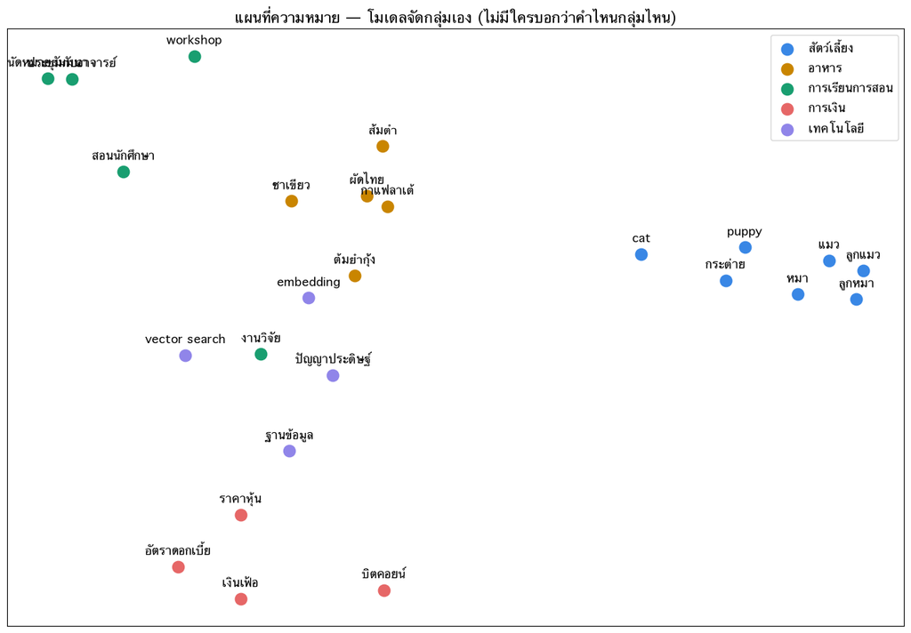

```python
import matplotlib.pyplot as plt

COLORS = {'สัตว์เลี้ยง': '#3987e5', 'อาหาร': '#c98500', 'การเรียนการสอน': '#199e70',
          'การเงิน': '#e66767', 'เทคโนโลยี': '#9085e9'}

fig, ax = plt.subplots(figsize=(13, 9))
for g in WORDS:
    idx = [i for i, gg in enumerate(groups) if gg == g]
    ax.scatter(P[idx, 0], P[idx, 1], s=140, c=COLORS[g], label=g, zorder=3)
for i, w in enumerate(labels):
    ax.annotate(w, (P[i, 0], P[i, 1]), textcoords='offset points',
                xytext=(0, 12), ha='center', fontsize=12)
ax.legend(fontsize=12, loc='best')
ax.set_title('แผนที่ความหมาย — โมเดลจัดกลุ่มเอง (ไม่มีใครบอกว่าคำไหนกลุ่มไหน)', fontsize=15)
ax.set_xticks([]); ax.set_yticks([])
plt.tight_layout(); plt.show()
```

## ขั้นที่ 6 — เส้นเพื่อนบ้าน: ใครใกล้ใคร (พร้อมกันความเข้าใจผิด)

วาดเส้นจากทุกคำไปเพื่อนใกล้สุด — **เฉพาะคู่ที่ cosine ≥ 0.7** (โซนเขียว) คำที่ไม่มีเส้น = คำโดดเดี่ยว ไม่ใช่ระบบพัง

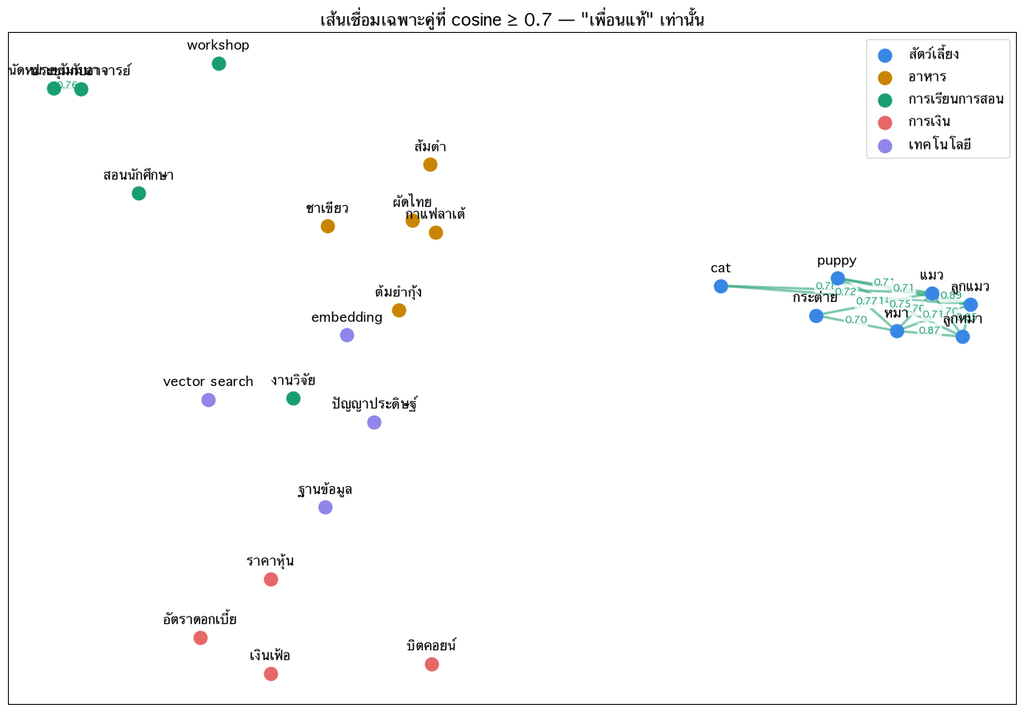

```
คำโดดเดี่ยว (ไม่มีเพื่อนถึง 0.7): ต้มยำกุ้ง, ผัดไทย, ส้มตำ, กาแฟลาเต้, ชาเขียว, workshop, สอนนักศึกษา, งานวิจัย, บิตคอยน์, ราคาหุ้น, อัตราดอกเบี้ย, เงินเฟ้อ, vector search, embedding, ปัญญาประดิษฐ์, ฐานข้อมูล
```

```python
fig, ax = plt.subplots(figsize=(13, 9))
THRESHOLD = 0.7
for i in range(len(labels)):
    for j in range(i + 1, len(labels)):
        if S[i, j] >= THRESHOLD:
            ax.plot([P[i, 0], P[j, 0]], [P[i, 1], P[j, 1]], '-',
                    color='#199e70', alpha=0.55, lw=2.2, zorder=1)
            mx, my = (P[i, 0]+P[j, 0])/2, (P[i, 1]+P[j, 1])/2
            ax.annotate(f'{S[i, j]:.2f}', (mx, my), fontsize=9, color='#199e70',
                        ha='center', bbox=dict(boxstyle='round,pad=0.15', fc='white', ec='none', alpha=.8))
for g in WORDS:
    idx = [i for i, gg in enumerate(groups) if gg == g]
    ax.scatter(P[idx, 0], P[idx, 1], s=140, c=COLORS[g], label=g, zorder=3)
for i, w in enumerate(labels):
    ax.annotate(w, (P[i, 0], P[i, 1]), textcoords='offset points', xytext=(0, 12), ha='center', fontsize=12)
ax.legend(fontsize=12); ax.set_xticks([]); ax.set_yticks([])
ax.set_title(f'เส้นเชื่อมเฉพาะคู่ที่ cosine ≥ {THRESHOLD} — "เพื่อนแท้" เท่านั้น', fontsize=15)
plt.tight_layout(); plt.show()

lonely = [labels[i] for i in range(len(labels)) if max(S[i, j] for j in range(len(labels)) if j != i) < THRESHOLD]
print('คำโดดเดี่ยว (ไม่มีเพื่อนถึง 0.7):', ', '.join(lonely))
```

## สรุป — สิ่งที่ notebook นี้พิสูจน์

1. **โมเดลจัดกลุ่มเอง** — เราไม่เคยบอกชื่อกลุ่ม แต่คำกองตามความหมาย
2. **ข้ามภาษาได้จริง** — cat อยู่กับ แมว (0.781) เพราะ bge-m3 เทรนข้ามภาษา
3. **คะแนนต้องอ่านเป็น** — ต่ำกว่า 0.55 = แทบไม่เกี่ยว แม้จะเป็น "อันดับ 1" ก็ตาม
4. **ภาพ 2D คือภาพประกอบ** — PCA ทิ้งข้อมูลไปมาก ตัวเลข cosine คือความจริง

### ไปต่อ

- แก้ `WORDS` เป็นข้อมูลของคุณ (หัวข้อวิจัย, โน้ต, อะไรก็ได้) แล้วรันใหม่
- ต่อยอดเป็น second brain เต็มรูป: หนังสือบทที่ 1-3 (ChromaDB + bge-m3 + filter)
- ทฤษฎีเบื้องหลังทุกขั้น: `deep-technical/` 86 บท

*ประกอบหนังสือ "Second Brain ด้วย Vector Search" · ARRA Oracle Workshop 26 ก.ค. 2026*